# Ford GoBike Data

## Introduction

> In this day of age with everything starting to be modernized and advanced specially when it comes to transportation, cars and buses aren't the only way to get around anymore. This takes us to the modern idea of bike sharing that we will be analyzing today.

> What is bike sharing? A bicycle-sharing system, public bicycle scheme or public bike share (PBS) scheme, is a service in which bicycles are made available for shared use to individuals on a short term basis for a price or free. Many bike share systems allow people to borrow a bike from a "dock" and return it at another dock belonging to the same system. Docks are special bike racks that lock the bike, and only release it by computer control. The user enters payment information, and the computer unlocks a bike. The user returns the bike by placing it in the dock, which locks it in place.

> That is why we will be analyzing the dataset of Ford GoBike which is a bike sharing provider through exploratory analysis until we get to the explanatory analysis

## Preliminary Wrangling

> It's time to collect and explore our data. In this project, we will focus on the record of individual trips taken in 2018.  
> Ford GoBike Data: https://s3.amazonaws.com/fordgobike-data/index.html

```python
# import all packages and set plots to be embedded inline
import numpy as np
import pandas as pd
import matplotlib.pyplot as plt
import seaborn as sns
import glob
import os
import requests
from io import BytesIO
from zipfile import ZipFile
%matplotlib inline
```

> All zip folders were then transformed into CSV and then I used the below code to merge all data and create one dataset

```python
#Creating the file we'll be storing our data in
os.makedirs('ford-gobike-trip-data')
```

```python
#Downloading all the other files
urls = ['https://s3.amazonaws.com/fordgobike-data/201801-fordgobike-tripdata.csv.zip',
        'https://s3.amazonaws.com/fordgobike-data/201802-fordgobike-tripdata.csv.zip',
        'https://s3.amazonaws.com/fordgobike-data/201803-fordgobike-tripdata.csv.zip',
        'https://s3.amazonaws.com/fordgobike-data/201804-fordgobike-tripdata.csv.zip',
        'https://s3.amazonaws.com/fordgobike-data/201805-fordgobike-tripdata.csv.zip',
        'https://s3.amazonaws.com/fordgobike-data/201806-fordgobike-tripdata.csv.zip',
        'https://s3.amazonaws.com/fordgobike-data/201807-fordgobike-tripdata.csv.zip',
        'https://s3.amazonaws.com/fordgobike-data/201808-fordgobike-tripdata.csv.zip',
        'https://s3.amazonaws.com/fordgobike-data/201809-fordgobike-tripdata.csv.zip',
        'https://s3.amazonaws.com/fordgobike-data/201810-fordgobike-tripdata.csv.zip',
        'https://s3.amazonaws.com/fordgobike-data/201811-fordgobike-tripdata.csv.zip',
        'https://s3.amazonaws.com/fordgobike-data/201812-fordgobike-tripdata.csv.zip']

for url in urls:
    response = requests.get(url)
    zip_file = ZipFile(BytesIO(response.content))
    zip_file.extractall('ford-gobike-trip-data')
```

```python
#Concatenating together all the datasets into a dataframe
path = r'ford-gobike-trip-data'
raw_dfs = []

for file in os.listdir(path):
    raw_dfs.append(pd.read_csv(path + '/' + file))
```

```python
#Stitching the datasets together into a dataframe
df = pd.concat(raw_dfs, sort=False)
```

```python
print(df.shape)
df.info()
```

```
(1863721, 16)
<class 'pandas.core.frame.DataFrame'>
Int64Index: 1863721 entries, 0 to 131362
Data columns (total 16 columns):
 #   Column                   Dtype
---  ------                   -----
 0   duration_sec             int64
 1   start_time               object
 2   end_time                 object
 3   start_station_id         float64
 4   start_station_name       object
 5   start_station_latitude   float64
 6   start_station_longitude  float64
 7   end_station_id           float64
 8   end_station_name         object
 9   end_station_latitude     float64
 10  end_station_longitude    float64
 11  bike_id                  int64
 12  user_type                object
 13  member_birth_year        float64
 14  member_gender            object
 15  bike_share_for_all_trip  object
dtypes: float64(7), int64(2), object(7)
memory usage: 241.7+ MB
```

### What is the structure of your dataset?

> The dataset contains 1,863,721 rows and 16 columns. It consists of the information gathered about the Ford GoBike trips done in 2018. The information is the duration for each trip, start time, end time and all the information of the start station and end station. Also, it includes all the information needed about the bike and the user. The user if they are a member or not, what's their birthdate and their gender.

### What is/are the main feature(s) of interest in your dataset?

> First of all, I think the main features are the duration of each trip, the age and the mean age of the users and how does that affect the duration. Also, the time of year that most likely has more trips or less trips, but this will need more columns that are not yet done, but will be done. Moreover, the gender of the users and how mainly dominates the number of trips. This will all be checked thoroughly in order to help this business thrive and reach more target audience.

### What features in the dataset do you think will help support your investigation into your feature(s) of interest?

> As mentioned above the duration, start and end times, the gender, age and subscribers or not. All of these will be used to get to the insights that we want to know. Some are start forward others like the monthly, weekly and daily trips will need more analysis in order to get to the bottom of these analysis.

## Data Cleaning

```python
df.info(verbose=True, null_counts=True);
```

```
<class 'pandas.core.frame.DataFrame'>
Int64Index: 1863721 entries, 0 to 131362
Data columns (total 16 columns):
 #   Column                   Non-Null Count    Dtype
---  ------                   --------------    -----
 0   duration_sec             1863721 non-null  int64
 1   start_time               1863721 non-null  object
 2   end_time                 1863721 non-null  object
 3   start_station_id         1851950 non-null  float64
 4   start_station_name       1851950 non-null  object
 5   start_station_latitude   1863721 non-null  float64
 6   start_station_longitude  1863721 non-null  float64
 7   end_station_id           1851950 non-null  float64
 8   end_station_name         1851950 non-null  object
 9   end_station_latitude     1863721 non-null  float64
 10  end_station_longitude    1863721 non-null  float64
 11  bike_id                  1863721 non-null  int64
 12  user_type                1863721 non-null  object
 13  member_birth_year        1753003 non-null  float64
 14  member_gender            1753354 non-null  object
 15  bike_share_for_all_trip  1863721 non-null  object
dtypes: float64(7), int64(2), object(7)
memory usage: 241.7+ MB
```

```python
df.dropna(inplace= True)
```

First, as you can see there are columns like station ids that are using float types which take up alot of memory for no reason and we dont even need these columns in our analysis. Same goes to latitude and longitudes as our analysis will not focus on the locations of the trips.

```python
# Let's drop the columns that we do not need in our dataset
df.drop(['start_station_id','start_station_latitude','start_station_longitude','end_station_id','end_station_latitude','end_station_longitude'], axis = 1, inplace=True)
```

```python
df.info()
```

```
<class 'pandas.core.frame.DataFrame'>
Int64Index: 1741556 entries, 0 to 131361
Data columns (total 10 columns):
 #   Column                   Dtype
---  ------                   -----
 0   duration_sec             int64
 1   start_time               object
 2   end_time                 object
 3   start_station_name       object
 4   end_station_name         object
 5   bike_id                  int64
 6   user_type                object
 7   member_birth_year        float64
 8   member_gender            object
 9   bike_share_for_all_trip  object
dtypes: float64(1), int64(2), object(7)
memory usage: 146.2+ MB
```

```python
# Checking to see if there are any null values in the dataset
df.isnull().all()
```

```
duration_sec               False
start_time                 False
end_time                   False
start_station_name         False
end_station_name           False
bike_id                    False
user_type                  False
member_birth_year          False
member_gender              False
bike_share_for_all_trip    False
dtype: bool
```

```python
# Checking to see if there are any duplicates in the dataset
df.duplicated().any()
```

```
False
```

The start time and the end time columns are considered as objects so we need to change them to datetime so we can manipulate them easily

```python
df['start_time'] = pd.to_datetime(df['start_time'], errors='coerce')
df['end_time'] = pd.to_datetime(df['end_time'], errors='coerce')

# Check if the columns were converted
df.info()
```

```
<class 'pandas.core.frame.DataFrame'>
Int64Index: 1741556 entries, 0 to 131361
Data columns (total 10 columns):
 #   Column                   Dtype
---  ------                   -----
 0   duration_sec             int64
 1   start_time               datetime64[ns]
 2   end_time                 datetime64[ns]
 3   start_station_name       object
 4   end_station_name         object
 5   bike_id                  int64
 6   user_type                object
 7   member_birth_year        float64
 8   member_gender            object
 9   bike_share_for_all_trip  object
dtypes: datetime64[ns](2), float64(1), int64(2), object(5)
memory usage: 146.2+ MB
```

```python
df.info(verbose=True, null_counts=True);
```

```
<class 'pandas.core.frame.DataFrame'>
Int64Index: 1741556 entries, 0 to 131361
Data columns (total 10 columns):
 #   Column                   Non-Null Count    Dtype
---  ------                   --------------    -----
 0   duration_sec             1741556 non-null  int64
 1   start_time               1741556 non-null  datetime64[ns]
 2   end_time                 1741556 non-null  datetime64[ns]
 3   start_station_name       1741556 non-null  object
 4   end_station_name         1741556 non-null  object
 5   bike_id                  1741556 non-null  int64
 6   user_type                1741556 non-null  object
 7   member_birth_year        1741556 non-null  float64
 8   member_gender            1741556 non-null  object
 9   bike_share_for_all_trip  1741556 non-null  object
dtypes: datetime64[ns](2), float64(1), int64(2), object(5)
memory usage: 146.2+ MB
```

Also, the bike id and member birth year are both float columns so they are taking up memory and time for no reason that is why they will be converted to integers

```python
df['bike_id'] = df['bike_id'].astype(int)
df['member_birth_year'] = df['member_birth_year'].astype(int)
```

Now, we want to get the specific age of each user and then we will also divide the dates to months, days and time of day in order to make futher analysis

```python
# Subtracting 2018  from the birth year of the user to get the age, but from the year of the information
# handled not from the year the analysis was made
df['age'] = 2018 - df['member_birth_year']
```

```python
df.drop(['member_birth_year'], axis = 1, inplace = True)
```

```python
#Let's investigate the age numbers in order to see if there are any outliers for very old people
df.age.describe()
```

```
count    1.741556e+06
mean     3.493921e+01
std      1.045133e+01
min      1.800000e+01
25%      2.700000e+01
50%      3.300000e+01
75%      4.000000e+01
max      1.370000e+02
Name: age, dtype: float64
```

As we can see that the average age is around 35 years old if we double that it would be 70 and as you can see that 75% of the data is under the age of 40. Another thing is that the max age is 137 which is not logical and will affect our analysis. Therefore, I think it is best to work with ages under 70 for better analysis and to avoid outliers.

```python
df.loc[df.age> 70 , ['age']].value_counts()
```

[output not shown]

```python
df.drop(df[df.age >70].index.tolist(),axis = 0, inplace=True)
df.reset_index(inplace=True, drop=True)
```

```python
# Dividing the datetime column to Month, Day, and hour
df['start_time_month']=df['start_time'].dt.month.astype(int)
df['start_time_day']=df['start_time'].dt.day.astype(int)
df['start_time_hour']=df['start_time'].dt.hour
df['start_day_name']=df['start_time'].dt.strftime('%a')
df['start_month_name']=df['start_time'].dt.strftime('%B')
```

```python
df.head()
```

|  | duration_sec | start_time | end_time | start_station_name | end_station_name | bike_id | user_type | member_gender | bike_share_for_all_trip | age | start_time_month | start_time_day | start_time_hour | start_day_name | start_month_name |
| --- | --- | --- | --- | --- | --- | --- | --- | --- | --- | --- | --- | --- | --- | --- | --- |
| 0 | 75284 | 2018-01-31 22:52:35.239 | 2018-02-01 19:47:19.824 | Mission Dolores Park | Webster St at O'Farrell St | 2765 | Subscriber | Male | No | 32 | 1 | 31 | 22 | Wed | January |
| 1 | 71576 | 2018-01-31 14:23:55.889 | 2018-02-01 10:16:52.116 | Jackson St at 5th St | 5th St at Virginia St | 3039 | Customer | Male | No | 22 | 1 | 31 | 14 | Wed | January |
| 2 | 39966 | 2018-01-31 19:52:24.667 | 2018-02-01 06:58:31.053 | Laguna St at Hayes St | Post St at Kearny St | 617 | Subscriber | Male | No | 27 | 1 | 31 | 19 | Wed | January |
| 3 | 453 | 2018-01-31 23:53:53.632 | 2018-02-01 00:01:26.805 | 17th & Folsom Street Park (17th St at Folsom St) | Valencia St at 24th St | 3571 | Subscriber | Male | No | 30 | 1 | 31 | 23 | Wed | January |
| 4 | 180 | 2018-01-31 23:52:09.903 | 2018-01-31 23:55:10.807 | Berry St at 4th St | 4th St at Mission Bay Blvd S | 1403 | Subscriber | Male | No | 38 | 1 | 31 | 23 | Wed | January |

Last but not least, changing the duration to minuted for better understanding of the trip duration

```python
df['duration_sec'] = df['duration_sec'] / 60
```

```python
df.rename(columns={'duration_sec':'duration_min'}, inplace = True)
df.head()
```

|  | duration_min | start_time | end_time | start_station_name | end_station_name | bike_id | user_type | member_gender | bike_share_for_all_trip | age | start_time_month | start_time_day | start_time_hour | start_day_name | start_month_name |
| --- | --- | --- | --- | --- | --- | --- | --- | --- | --- | --- | --- | --- | --- | --- | --- |
| 0 | 1254.733333 | 2018-01-31 22:52:35.239 | 2018-02-01 19:47:19.824 | Mission Dolores Park | Webster St at O'Farrell St | 2765 | Subscriber | Male | No | 32 | 1 | 31 | 22 | Wed | January |
| 1 | 1192.933333 | 2018-01-31 14:23:55.889 | 2018-02-01 10:16:52.116 | Jackson St at 5th St | 5th St at Virginia St | 3039 | Customer | Male | No | 22 | 1 | 31 | 14 | Wed | January |
| 2 | 666.100000 | 2018-01-31 19:52:24.667 | 2018-02-01 06:58:31.053 | Laguna St at Hayes St | Post St at Kearny St | 617 | Subscriber | Male | No | 27 | 1 | 31 | 19 | Wed | January |
| 3 | 7.550000 | 2018-01-31 23:53:53.632 | 2018-02-01 00:01:26.805 | 17th & Folsom Street Park (17th St at Folsom St) | Valencia St at 24th St | 3571 | Subscriber | Male | No | 30 | 1 | 31 | 23 | Wed | January |
| 4 | 3.000000 | 2018-01-31 23:52:09.903 | 2018-01-31 23:55:10.807 | Berry St at 4th St | 4th St at Mission Bay Blvd S | 1403 | Subscriber | Male | No | 38 | 1 | 31 | 23 | Wed | January |

```python
# Rounding them to the nearest integer
df['duration_min'] = df['duration_min'].round(0).astype(int)
```

```python
df.head()
```

|  | duration_min | start_time | end_time | start_station_name | end_station_name | bike_id | user_type | member_gender | bike_share_for_all_trip | age | start_time_month | start_time_day | start_time_hour | start_day_name | start_month_name |
| --- | --- | --- | --- | --- | --- | --- | --- | --- | --- | --- | --- | --- | --- | --- | --- |
| 0 | 1255 | 2018-01-31 22:52:35.239 | 2018-02-01 19:47:19.824 | Mission Dolores Park | Webster St at O'Farrell St | 2765 | Subscriber | Male | No | 32 | 1 | 31 | 22 | Wed | January |
| 1 | 1193 | 2018-01-31 14:23:55.889 | 2018-02-01 10:16:52.116 | Jackson St at 5th St | 5th St at Virginia St | 3039 | Customer | Male | No | 22 | 1 | 31 | 14 | Wed | January |
| 2 | 666 | 2018-01-31 19:52:24.667 | 2018-02-01 06:58:31.053 | Laguna St at Hayes St | Post St at Kearny St | 617 | Subscriber | Male | No | 27 | 1 | 31 | 19 | Wed | January |
| 3 | 8 | 2018-01-31 23:53:53.632 | 2018-02-01 00:01:26.805 | 17th & Folsom Street Park (17th St at Folsom St) | Valencia St at 24th St | 3571 | Subscriber | Male | No | 30 | 1 | 31 | 23 | Wed | January |
| 4 | 3 | 2018-01-31 23:52:09.903 | 2018-01-31 23:55:10.807 | Berry St at 4th St | 4th St at Mission Bay Blvd S | 1403 | Subscriber | Male | No | 38 | 1 | 31 | 23 | Wed | January |

This ends the data cleaning and wrangling process

## Data Exploration

Throughout the data wrangling process, the different columns and entries in the dataset were assessed and cleaned, and now it's time to answer some research questions.

1. What's the monthly trend throughout 2018? Which seasons/months were the most trips taken?
2. What's the ratio of subscribers to customers?
   - What's the average trip duration for each?
   - What's the weekly trend for each? Do they use the bike sharing system during weekdays or weekend?
   - What's the hourly trend for each? Do most of the trips happen in the day or in the evening? What does that say about the objective of bike usage for each group?
   - What's the split of genders for the users in each group (subscribers and customers)?
3. How does the distribution of number of trips completed by age group look like?

## Univariate Exploration

```python
df.head()
```

|  | duration_min | start_time | end_time | start_station_name | end_station_name | bike_id | user_type | member_gender | bike_share_for_all_trip | age | start_time_month | start_time_day | start_time_hour | start_day_name | start_month_name |
| --- | --- | --- | --- | --- | --- | --- | --- | --- | --- | --- | --- | --- | --- | --- | --- |
| 0 | 1255 | 2018-01-31 22:52:35.239 | 2018-02-01 19:47:19.824 | Mission Dolores Park | Webster St at O'Farrell St | 2765 | Subscriber | Male | No | 32 | 1 | 31 | 22 | Wed | January |
| 1 | 1193 | 2018-01-31 14:23:55.889 | 2018-02-01 10:16:52.116 | Jackson St at 5th St | 5th St at Virginia St | 3039 | Customer | Male | No | 22 | 1 | 31 | 14 | Wed | January |
| 2 | 666 | 2018-01-31 19:52:24.667 | 2018-02-01 06:58:31.053 | Laguna St at Hayes St | Post St at Kearny St | 617 | Subscriber | Male | No | 27 | 1 | 31 | 19 | Wed | January |
| 3 | 8 | 2018-01-31 23:53:53.632 | 2018-02-01 00:01:26.805 | 17th & Folsom Street Park (17th St at Folsom St) | Valencia St at 24th St | 3571 | Subscriber | Male | No | 30 | 1 | 31 | 23 | Wed | January |
| 4 | 3 | 2018-01-31 23:52:09.903 | 2018-01-31 23:55:10.807 | Berry St at 4th St | 4th St at Mission Bay Blvd S | 1403 | Subscriber | Male | No | 38 | 1 | 31 | 23 | Wed | January |

> 1. What's the monthly trend throughout 2018? Which seasons/months were the most trips taken?

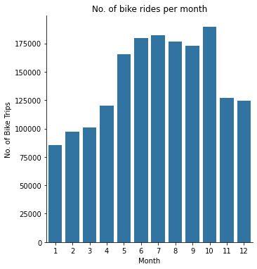

```python
# Getting the base color in order to use it so the output will only have one color
base_color = sns.color_palette()[0]

# Plotting the No of rides vs month
sns.catplot(data=df, x='start_time_month', kind='count', color=base_color)
plt.xlabel('Month');
plt.ylabel('No. of Bike Trips');
plt.title('No. of bike rides per month');
```

> As you can see, the number of bike rides increases when it comes to the best weather of the year whih is from June to October, but after that the weather starts to be colder and the bike riding decreases.

### There are 2 different types of users: Customers vs Subscribers

> 1. What's the ratio of subscribers to customers?

```python
# First, we need to calculate the percentage of users for each type from the total
# we use the query and count functions to get the number of subscribers an customers
subscriber_count = df.query('user_type == "Subscriber"')['bike_id'].count()
customer_count = df.query('user_type == "Customer"')['bike_id'].count()

# Then, we divide by the total count of bikes to get the percentage
subscriber_percentage = subscriber_count / df['bike_id'].count()
customer_percentage = customer_count / df['bike_id'].count()
```

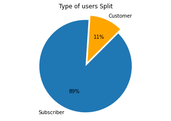

```python
# We will know plot a pie chart as it is very efficient when it comes to relative frequencies for categorical variables
labels = ['Customer', 'Subscriber']
sizes = [customer_percentage, subscriber_percentage]

plt.pie(sizes, explode=(0,0.1), labels=labels, colors = ['orange', base_color],
        autopct='%1.0f%%', shadow=False, startangle=45)
plt.axis('equal')

plt.title('Type of users Split');
```

### The different age groups and their bike rides

> 1. How does the distribution of number of trips completed by age group look like?

```python
# We create bins in order to be able to classify the age groups into 10 year groups
df['age_group'] = df['age'].apply(lambda x: '10 - 20' if 10<x<=20
                                                  else '20 - 30' if 20<x<=30
                                                  else '30 - 40' if 30<x<=40
                                                  else '40 - 50' if 40<x<=50
                                                  else '50 - 60' if 50<x<=60
                                                  else '60 - 70' if 60<x<=70
                                                  else x)
```

```python
age_group= df.groupby('age_group').agg({'bike_id':'count'})
```

```python
age_group['percentage'] = (age_group['bike_id']/age_group['bike_id'].sum())*100
```

```python
age_group
```

| age_group | bike_id | percentage |
| --- | --- | --- |
| 10 - 20 | 37601 | 2.183429 |
| 20 - 30 | 660400 | 38.348350 |
| 30 - 40 | 606932 | 35.243550 |
| 40 - 50 | 260207 | 15.109796 |
| 50 - 60 | 127354 | 7.395239 |
| 60 - 70 | 29614 | 1.719637 |

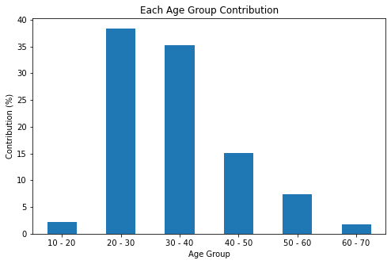

```python
age_group['percentage'].plot(kind='bar', color=base_color, figsize=(8,5))
plt.title('Each Age Group Contribution')
plt.xlabel('Age Group')
plt.xticks(rotation=360);
plt.ylabel('Contribution (%)');
```

> From the chart above, it seems that most users are twenty to thrity years of age. The second most common age group that uses the bikes are thirty to forty years old. It might be useful to look at the trend by month to get a feel of the behavior of each group throughout the different months of the year

> Monthly behavior of each Age Group

```python
customer_df = df[df['user_type']=='Customer'].groupby(['start_time_month', 'age_group']).agg({'bike_id':'count'}).reset_index()
customer_df
```

|  | start_time_month | age_group | bike_id |
| --- | --- | --- | --- |
| 0 | 1 | 10 - 20 | 200 |
| 1 | 1 | 20 - 30 | 2583 |
| 2 | 1 | 30 - 40 | 2285 |
| 3 | 1 | 40 - 50 | 719 |
| 4 | 1 | 50 - 60 | 356 |
| ... | ... | ... | ... |
| 67 | 12 | 20 - 30 | 6045 |
| 68 | 12 | 30 - 40 | 4310 |
| 69 | 12 | 40 - 50 | 1630 |
| 70 | 12 | 50 - 60 | 740 |
| 71 | 12 | 60 - 70 | 105 |

72 rows × 3 columns

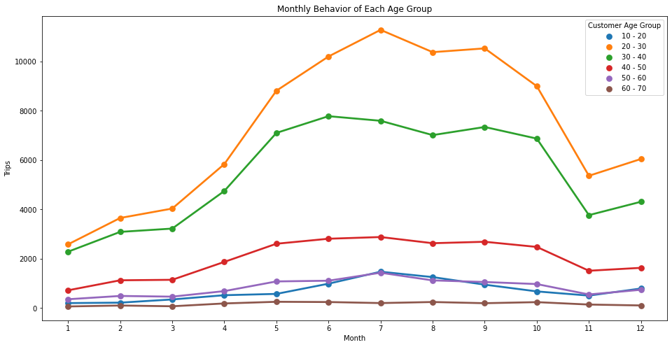

```python
plt.figure(figsize=(16,8))
ax = sns.pointplot(x='start_time_month', y='bike_id', hue='age_group', data=customer_df)
plt.title("Monthly Behavior of Each Age Group")
plt.xlabel('Month')
plt.ylabel('Trips')
leg = ax.legend()
leg.set_title('Customer Age Group')
```

> From the above visual, it seems that the behavior of the two most common age groups 20-30 and 30-40 are quite similar. The frequency of using the system increases significanty during the month of July. This can be assumed to be due to seasonality, however, we need to look at the hourly rates of using the bikes throughout the day to link them to working hours and other factors.

### Discuss the distribution(s) of your variable(s) of interest. Were there any unusual points? Did you need to perform any transformations?

> In this section, we examined the relation between the number of rides against the month and realized that it is somehow related to the weather. Also, we compared the percentage of the customers to the subscribers to this system. Lastly, we combined age groups to see the different contribution of each age group to the trips and futhermore, we investigated when does each age group usually bike in the different months of the year.

### Of the features you investigated, were there any unusual distributions? Did you perform any operations on the data to tidy, adjust, or change the form of the data? If so, why did you do this?

> The dataset was already ready for the analysis we explored. Only the age bins were not ready so we had to creat them using the lambda function. The function helped us create the bins in order to be able to see the effect of each age group on the number of trips.

## Bivariate Exploration

> In this section, investigate relationships between pairs of variables in your data. Make sure the variables that you cover here have been introduced in some fashion in the previous section (univariate exploration).
1. What's the ratio of subscribers to customers?
   - What's the average trip duration for each?

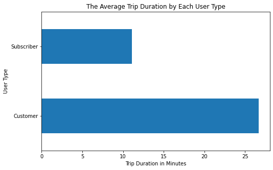

```python
# let's see the average duration of the trips completed by each user category
# First, find the mean duration for each user
mean_dur = df.groupby('user_type')['duration_min'].mean()


mean_dur.plot(kind='barh', color=base_color, figsize=(8,5))

plt.title('The Average Trip Duration by Each User Type')
plt.xlabel('Trip Duration in Minutes')
plt.ylabel('User Type');
```

> The graph above shows that customers usually spend more than 25 minutes on their bike which is a lot of time compared to the 10 minutes average of subscribers. This is not entirely strange as usually subscribers use this service for work commuting purposes only that is why they take a lot less time compared to customers. As customers usually take those rides for fun and leisure time which could take a lot of time. This will be furtherly explored through days of weeks and times of day to check if they correspond with working hours or not.
1. What's the ratio of subscribers to customers?
   - What's the distribution throughout the week?

[figure not shown]

```python
# Setting the order of the days for better view
days=['Mon','Tue','Wed','Thu','Fri','Sat','Sun']

# Plotting the 2 plots of Subscriber and Customers and seeing both their trips vs the day of the week
g = sns.catplot(data=df, x='start_day_name', col="user_type", kind='count', sharey = False, color = base_color, order = days)
g.set_axis_labels("Day of Week", "Number of Trips")
g.set_titles("{col_name}")
g.fig.suptitle('Number of Trips per Week');
```

> As mentioned before that we suspected that customers use that for leisure not work and vice verse for the subscribers. This was proven in the above graphs as it shows that the subscribers use the bikes mainly on weekdays and not on weekends. On the other hand, the customers use the bikes on the weekends more than the weekdays as this is more a free time than the weekdays. To be extra sure, we will now investigate the time of the day that has the most trips for both user types.
1. What's the ratio of subscribers to customers?
   - What's the hourly trend for each? Do most of the trips happen in the day or in the evening? What does that say about the objective of bike usage for each group?

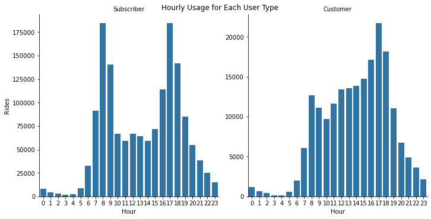

```python
# Plotting the 2 plots of Subscriber and Customers and seeing both their trips vs the time of day
g = sns.catplot(data=df, x='start_time_hour', col="user_type", kind='count', sharey = False, color = base_color)
g.set_axis_labels("Hour", "Rides")
g.set_titles("{col_name}")
g.fig.suptitle('Hourly Usage for Each User Type');
```

> Again, the above charts support the assumption we have been discussing, because apparently subscribers use their bikes the most between 7AM-9AM and then again between 5PM-7PM. These are the most typical working hours times for anyone. Customers, however, either use the bikes during the day (and we have previsouly seen how they mostly use it during weekends) for leisure purposes, or use them specifically post working hours (starting 6pm)

### Talk about some of the relationships you observed in this part of the investigation. How did the feature(s) of interest vary with other features in the dataset?

> In this section, we were mostly trying to dive deeper in the behavior of each user type. We started by calculating the average trip duration to get a feel of how much time each type spends on the bike. Then, we further explored the days of the week, as well as the time of the day, where most trips take place.

> As a general conclusion, it's safe to say that people who subscribe to this service would usually take it as a way to commute to and from work, while others just use it for leisure purposes on weekends and post the working hours.

### Did you observe any interesting relationships between the other features (not the main feature(s) of interest)?

> Yes, through making those extra columns that were needed for this analysis like the month and hourly columns. They were both used to dig deeper into the dataset and understand the behavior of each type of users even more.

## Multivariate Exploration

> 1. What's the ratio of subscribers to customers?
>    - What's the split of genders for the users in each group (subscribers and customers)?

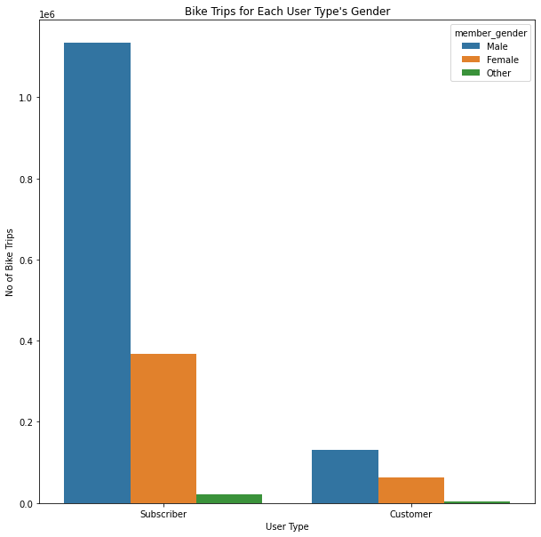

```python
# Setting the order for better view
order = df.user_type.value_counts().index

#Setting Figure Size for better view
plt.figure(figsize = [10, 10])

# Plotting Bike Trips for Each User Type's Gender
sns.countplot(data=df, x='user_type', hue="member_gender", order = order)

plt.xlabel('User Type')
plt.ylabel('No of Bike Trips')
plt.title("Bike Trips for Each User Type's Gender");
```

> From the charts above, it seems that the males are dominating the subscribers portion of the user types. We might need further analysis to investigate why this is the case but an initial assumption can be made, linking all observations to each other, claiming that the males might be dominating the working class. Which would make sense given that they have the highest contribution in trips completed by subscribers, which were proven to be using the bikes to commute to work. But for the customers portion, the males are still more than the females, but the difference is not that huge as of the subscribers. This will need further investigation to understand why this is the case. Maybe, the females need more ads or encouragement to be using the bikes.

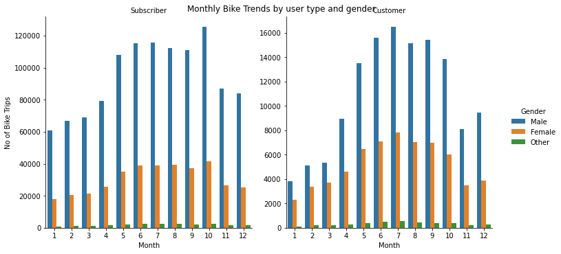

```python
#Checking the behavior of each gender throughout the months of 2018 by user type
g = sns.catplot(data=df, x='start_time_month', col="user_type", hue="member_gender", kind='count', sharey = False)

g.set_axis_labels("Month", "No of Bike Trips")
g._legend.set_title('Gender')
g.set_titles("{col_name}")
g.fig.suptitle('Monthly Bike Trends by user type and gender');
```

> After futher investigating, we can see that still males dominate the customers as they dominate the subscribers. Still we do not know the exact reasom behind that. Also, it seems that all genders have similar trends when it comes to their consumpotion throughout the time of the year. This is due to the good weather associated with the peaks that we can see on the graph above. And the similar trends of gender is very plausible as the gender has nothing to do with the weather.

### Talk about some of the relationships you observed in this part of the investigation. Were there features that strengthened each other in terms of looking at your feature(s) of interest?

> In this part, we split the user types into genders to check if there is any assumptions or conclusions that can be drawn of the behavior of each from the data. It seems however that all genders have similar trends whether they are subscribers or customers. However, there were interesting findings regarding the gender split in general

### Were there any interesting or surprising interactions between features?

> I was surprised to see that males dominate the subsribers category of the user, which was proven earlier to mostly use the service to commute to work. This might give us an insight that males dominate the working class. This is a general assumption, however, that I recommend to be proven using deeper analysis including more factors to be able to reach a final conclusion in this topic.

```python
df.to_csv('df.csv',encoding='utf-8',index=False)
```

## Conclusion

> In conclusion, the bike service looks like it needs to gear up for the winter and try to get more customers to use them. Moreover, the age grouping that was done above helps them know who uses the bike service more than the others. Also, they may have more packages or something for users in order to have more subscribers other than the working force. Another thing is the low number of woman riders for either customers or subscribers and they need to fix this in order to get more users. This would be my recommendations for getting better results off of this system.